# Diamond paradox

2022-09-13

How can there be a negative correlation between the **quality of the cut** and the **price** of a diamond? This work describes this fascinating and educational puzzle.

Diamonds is a famous training data set with almost 54,000 round diamonds. It comes with ggplot2, which is a part of tidyverse.

## 1. Preparation

```r
library(tidyverse)
library(modelr)
library(knitr)

cut_colors = c("#C76E32", "#A8A846", "#46A846",
               "#3584B8", "#555599")
```

Price of diamonds in this data set is capped at around $18,800. Here are the top 2 most valuable ones for each quality of cut.

```r
diamonds |>
  group_by(cut) |>
  slice_max(order_by = price, n = 2) |>
  kable(caption = "Top diamond prices are very similar")
```

Top diamond prices are very similar

| carat | cut | color | clarity | depth | table | price | x | y | z |
| --- | --- | --- | --- | --- | --- | --- | --- | --- | --- |
| 2.01 | Fair | G | SI1 | 70.6 | 64 | 18574 | 7.43 | 6.64 | 4.69 |
| 2.02 | Fair | H | VS2 | 64.5 | 57 | 18565 | 8.00 | 7.95 | 5.14 |
| 2.80 | Good | G | SI2 | 63.8 | 58 | 18788 | 8.90 | 8.85 | 0.00 |
| 2.07 | Good | I | VS2 | 61.8 | 61 | 18707 | 8.12 | 8.16 | 5.03 |
| 2.00 | Very Good | G | SI1 | 63.5 | 56 | 18818 | 7.90 | 7.97 | 5.04 |
| 2.00 | Very Good | H | SI1 | 62.8 | 57 | 18803 | 7.95 | 8.00 | 5.01 |
| 2.29 | Premium | I | VS2 | 60.8 | 60 | 18823 | 8.50 | 8.47 | 5.16 |
| 2.29 | Premium | I | SI1 | 61.8 | 59 | 18797 | 8.52 | 8.45 | 5.24 |
| 1.51 | Ideal | G | IF | 61.7 | 55 | 18806 | 7.37 | 7.41 | 4.56 |
| 2.07 | Ideal | G | SI2 | 62.5 | 55 | 18804 | 8.20 | 8.13 | 5.11 |

This price ceiling can hide the real connection between the variables, so to lessen that effect I’m going to filter out those diamonds that are larger or equal to 1.75 Ct. The exact number was selected arbitrarily.

```r
d <- diamonds |>
  filter(carat < 1.75)

paste("Only", nrow(diamonds) - nrow(d), "rows were removed.")
```

```
## [1] "Only 2417 rows were removed."
```

```r
d |>
  group_by(cut) |>
  slice_max(order_by = price, n = 2) |>
  kable(caption = "Prices are still pretty similar for higher quality diamonds,
        but I don't want to filter too much")
```

Prices are still pretty similar for higher quality diamonds, but I don’t want to filter too much

| carat | cut | color | clarity | depth | table | price | x | y | z |
| --- | --- | --- | --- | --- | --- | --- | --- | --- | --- |
| 1.50 | Fair | F | VVS2 | 64.7 | 53 | 16364 | 7.22 | 7.15 | 4.65 |
| 1.50 | Fair | E | VS1 | 65.4 | 57 | 15584 | 7.14 | 7.07 | 4.65 |
| 1.70 | Good | F | VS2 | 62.2 | 56 | 17597 | 7.54 | 7.60 | 4.71 |
| 1.14 | Good | D | IF | 61.7 | 63 | 17499 | 6.64 | 6.74 | 4.13 |
| 1.51 | Very Good | F | VVS1 | 62.6 | 59 | 18777 | 7.33 | 7.24 | 4.56 |
| 1.50 | Very Good | G | VS2 | 60.7 | 59 | 18691 | 7.31 | 7.38 | 4.46 |
| 1.71 | Premium | F | VS2 | 62.3 | 59 | 18791 | 7.57 | 7.53 | 4.70 |
| 1.72 | Premium | G | VVS2 | 61.8 | 60 | 18730 | 7.65 | 7.68 | 4.74 |
| 1.51 | Ideal | G | IF | 61.7 | 55 | 18806 | 7.37 | 7.41 | 4.56 |
| 1.60 | Ideal | F | VS1 | 62.0 | 56 | 18780 | 7.47 | 7.52 | 4.65 |

## 2. Paradox

How does the quality of the cut affect the price of diamonds?

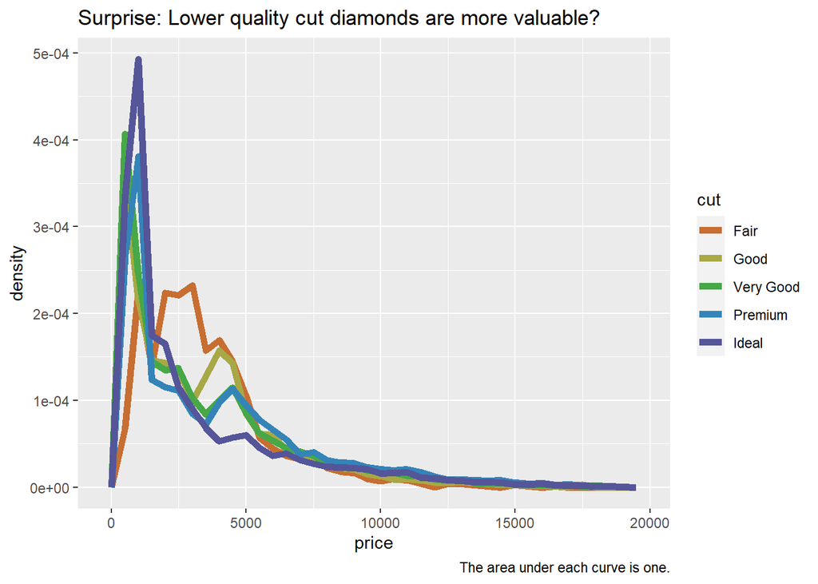

```r
ggplot(d, aes(price, after_stat(density), colour = cut)) +
  geom_freqpoly(binwidth = 500, size = 2) +
  scale_color_manual(values = cut_colors) +
  labs(title = "Surprise: Lower quality cut diamonds are more valuable?",
       caption = "The area under each curve is one.")
```

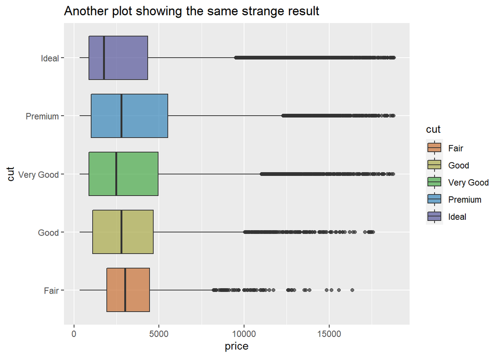

```r
ggplot(d, mapping = aes(x = price, fill = cut))+
  geom_boxplot(aes(y = cut), alpha = 0.7) +
  scale_fill_manual(values = cut_colors) +
  labs(title = "Another plot showing the same strange result")
```

## 3. Explanation

Lower quality cuts being more valuable can be explained by two other correlations.

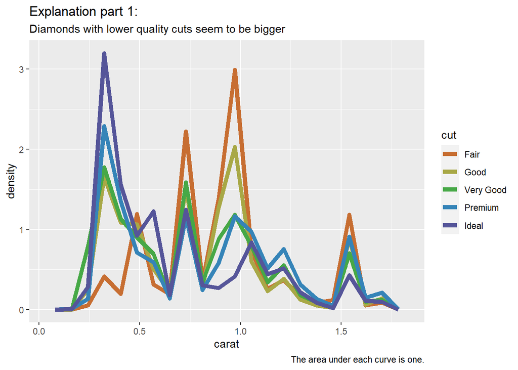

```r
ggplot(d, aes(x = carat, y = after_stat(density))) +
  geom_freqpoly(aes(colour = cut), size = 2, bins = 20) +
  scale_color_manual(values = cut_colors) +
  labs(title = "Explanation part 1:",
       subtitle= "Diamonds with lower quality cuts seem to be bigger",
       caption = "The area under each curve is one.")
```

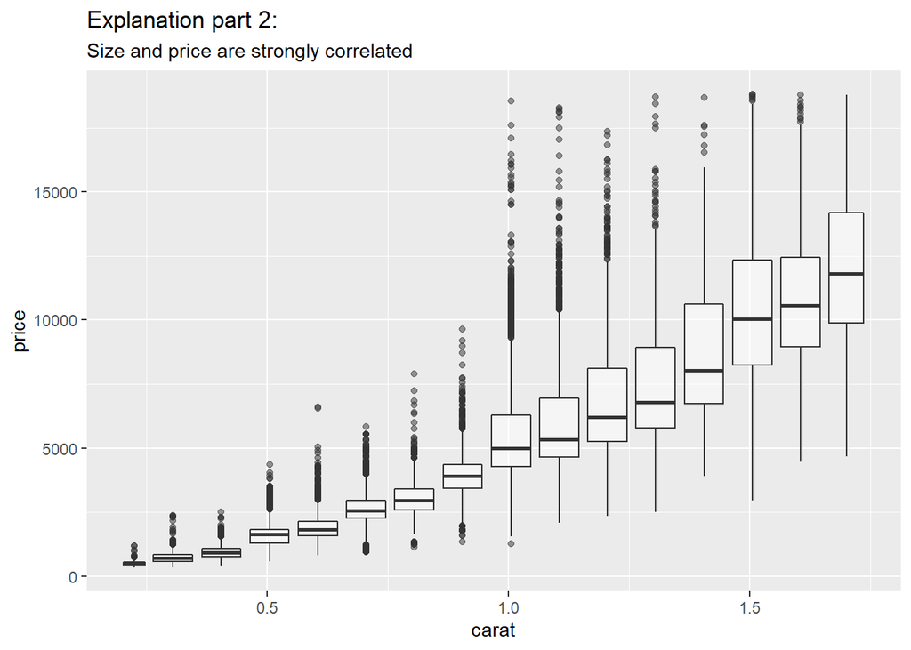

```r
ggplot(d, aes(x = carat, y = price)) +
  geom_boxplot(aes(group = cut_width(carat, 0.1)), alpha = 0.5) +
  labs(title = "Explanation part 2:",
       subtitle= "Size and price are strongly correlated")
```

## 4. Relationships between size and price.

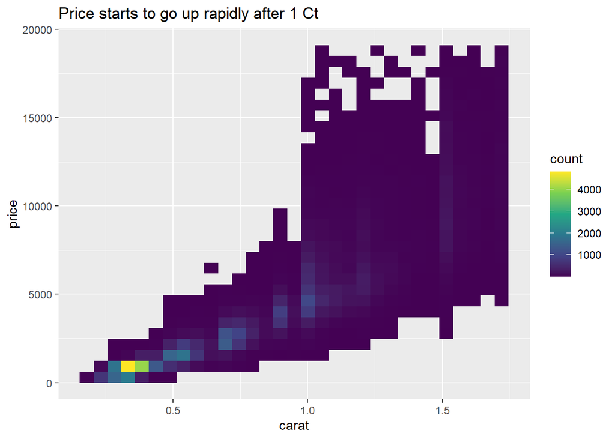

```r
ggplot(d, aes(carat, price)) +
  geom_bin2d() +
  scale_fill_continuous(type = "viridis") +
  labs(title = "Price starts to go up rapidly after 1 Ct")
```

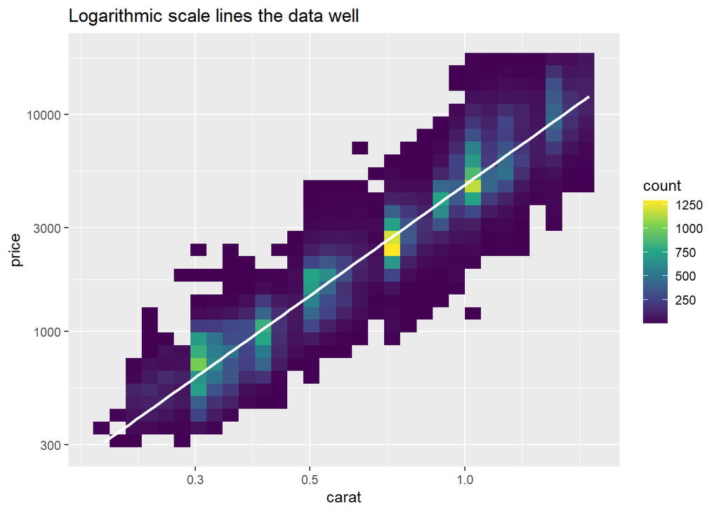

```r
ggplot(d, aes(carat, price)) +
  geom_bin2d() +
  scale_fill_continuous(type = "viridis") +
  geom_smooth(formula = y ~ x, method = "lm", color = "white") +
  scale_x_log10() +
  scale_y_log10() +
  labs(title = "Logarithmic scale lines the data well")
```

```r
model <- lm(log(price) ~ log(carat), d)
paste0("Linear model for unmodified data gives R-squared of ",
      round(summary(lm(price ~ carat, d))$r.squared, 2),
      ", but the logarithmic data gives ",
      round(summary(model)$r.squared, 2),
      ".")
```

```
## [1] "Linear model for unmodified data gives R-squared of 0.81, but the logarithmic data gives 0.93."
```

## 5. Adding residuals

Let’s add a new column for residuals.

```r
d |>
  lm(model, data = _) |>
  modelr::add_residuals(d, model = _) -> d
```

Residuals can be used to represent and calculate the difference between what the linear regression model predicts for price (based on size only) and its actual value.

```r
slope = summary(model)$coefficients[2]
intercept = summary(model)$coefficients[1]
paste0("The formula given by linear model is ",
       round(slope, 2),
       " * log(carat) + ",
       round(intercept, 2),
       " == log(price). It can explain ",
       round(summary(model)$r.squared[1]*100),
       " % of the price variation.")
```

```
## [1] "The formula given by linear model is 1.7 * log(carat) + 8.47 == log(price). It can explain 93 % of the price variation."
```

Formula works well when residuals are close to zero. But especially for those with either very bad or very good quality of cuts and colors the predictions are much worse.

```r
d |>
  slice_min(abs(resid), n = 3, with_ties = FALSE) -> low_resids

d |>
  slice_max(abs(resid), n = 3, with_ties = FALSE) -> high_resids

different_resids <- bind_rows(low_resids, high_resids) |>
  arrange(abs(resid)) |>
  mutate(price_predicted_by_size = round(exp(slope * log(carat) + intercept))) |>
  mutate(resid = round(resid, 5)) |>
  select(carat:clarity, resid, price, price_predicted_by_size)

kable(different_resids, caption = "Residuals closest to zero and farthest from it")
```

Residuals closest to zero and farthest from it

| carat | cut | color | clarity | resid | price | price_predicted_by_size |
| --- | --- | --- | --- | --- | --- | --- |
| 1.71 | Ideal | E | SI2 | 0.00001 | 11816 | 11816 |
| 1.20 | Ideal | H | SI1 | 0.00002 | 6471 | 6471 |
| 0.32 | Premium | F | SI1 | 0.00004 | 684 | 684 |
| 1.04 | Very Good | D | IF | 1.29602 | 18542 | 5073 |
| 0.30 | Very Good | D | VVS2 | 1.35076 | 2366 | 613 |
| 1.03 | Fair | E | I1 | -1.37490 | 1262 | 4991 |

For the bottom three diamonds the residual are very high, so the carat does poor job explaining the price.

## 6. Solving the paradox

Residuals represents the price where the effect of diamond’s size has been removed.

```r
tibble(residual = rep(c(1, 0.5, 0, -0.5, -1),2),
       carat = c(rep(0.5, 5), rep(1,5))) |>
  mutate(price =
           round(
           exp(residual) * #residual
           exp(slope * log(carat) + intercept) #size
           )) |>
  kable(caption = "Examples how residuals relate to price")
```

Examples how residuals relate to price

| residual | carat | price |
| --- | --- | --- |
| 1.0 | 0.5 | 3971 |
| 0.5 | 0.5 | 2408 |
| 0.0 | 0.5 | 1461 |
| -0.5 | 0.5 | 886 |
| -1.0 | 0.5 | 537 |
| 1.0 | 1.0 | 12901 |
| 0.5 | 1.0 | 7825 |
| 0.0 | 1.0 | 4746 |
| -0.5 | 1.0 | 2879 |
| -1.0 | 1.0 | 1746 |

Let’s look at the original mystery plots where instead of comparing cut to price we do the comparison against residuals.

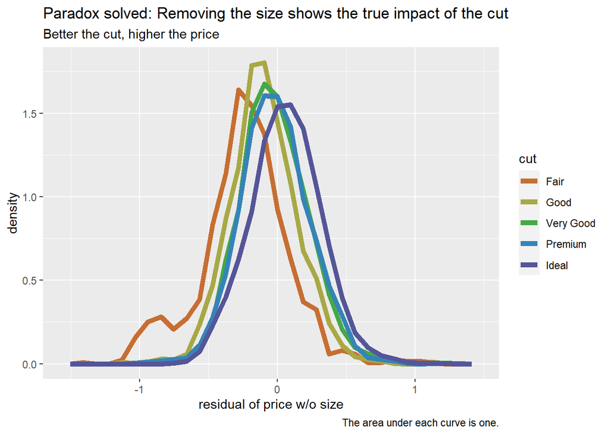

```r
ggplot(d, aes(resid, after_stat(density), colour = cut)) +
  geom_freqpoly(bins = 30, size = 2) +
  scale_color_manual(values = cut_colors) +
  labs(title = "Paradox solved: Removing the size shows the true impact of the cut",
       subtitle = "Better the cut, higher the price",
       caption = "The area under each curve is one.",
       x = "residual of price w/o size")
```

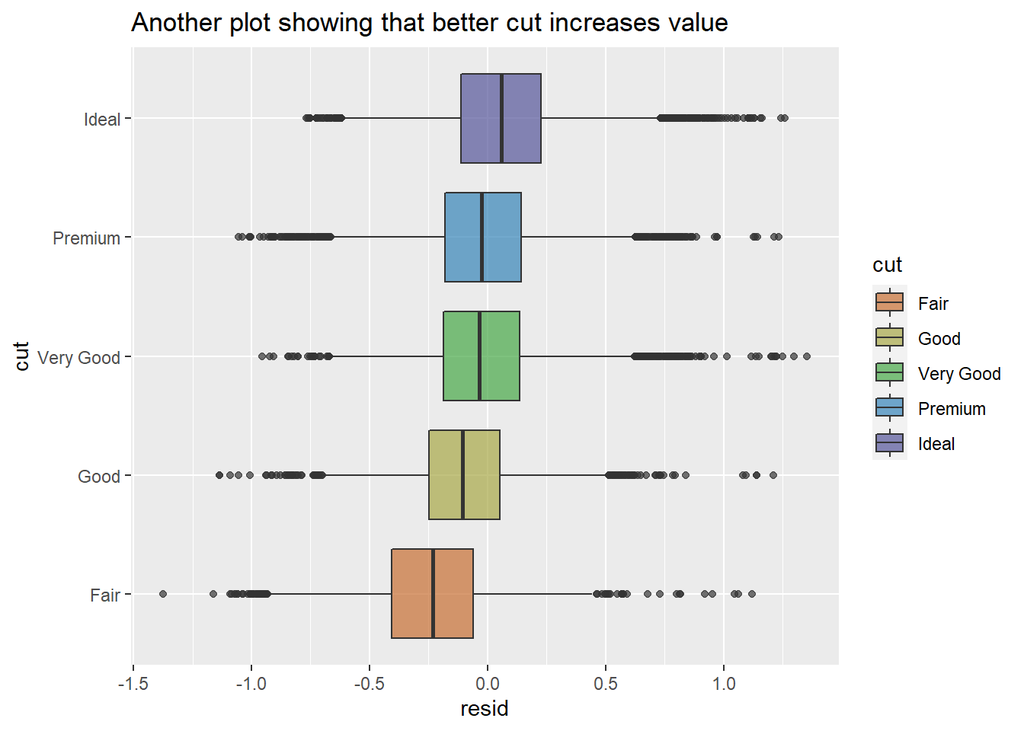

```r
ggplot(d, mapping = aes(x = resid, fill = cut))+
  geom_boxplot(aes(y = cut), alpha = 0.7) +
  scale_fill_manual(values = cut_colors) +
  labs(title = "Another plot showing that better cut increases value")
```

## 7. Conclusion

Diamonds is a classic of data analysis for a reason. It shows how a superficial analysis can lead to a completely opposite conclusion.

Initially it looks like lower quality cut diamonds are more valuable. Actual effect of the quality of cut on price is masked by two other correlations: lower quality cuts being larger and high correlation between the size and the price.

One way to remove this mask is to analyze the residuals where the effect of size on price has been removed. This more thorough analysis revealed that higher quality of cut is indeed correlated with higher price.